# MATH 4432 – Assignment 1

Coding parts: Chapter 2 exercises 8 and 10, Chapter 3 exercises 8 and 9. The conceptual exercises (Ch. 2: 1, 3; Ch. 3: 1, 5) are in the separate PDF.

```python
import numpy as np
import pandas as pd
import matplotlib.pyplot as plt
import seaborn as sns
import scipy.stats as stats
from scipy.stats import t
import statsmodels.api as sm
from statsmodels.formula.api import ols
from statsmodels.nonparametric.smoothers_lowess import lowess
from statsmodels.stats.diagnostic import het_breuschpagan
from ISLP import load_data

%matplotlib inline
```

Helper functions used in several exercises.

```python
def corr_heatmap(df, title, figsize=(11, 9)):
    """Annotated correlation heatmap of the numeric columns of df."""
    corr = df.corr(numeric_only=True)
    cols = corr.columns
    fig, ax = plt.subplots(figsize=figsize)
    im = ax.imshow(corr, cmap='RdBu_r', vmin=-1, vmax=1)
    ax.set_xticks(range(len(cols)))
    ax.set_yticks(range(len(cols)))
    ax.set_xticklabels(cols, rotation=90)
    ax.set_yticklabels(cols)
    for i in range(len(cols)):
        for j in range(len(cols)):
            ax.text(j, i, f'{corr.iloc[i, j]:.2f}', ha='center', va='center', fontsize=7,
                    color='white' if abs(corr.iloc[i, j]) > 0.6 else 'black')
    fig.colorbar(im, ax=ax, shrink=0.8, label='Correlation')
    ax.set_title(title)
    fig.tight_layout()
    plt.show()
    return corr


def strongest_pairs(corr, n_pos=8, n_neg=5):
    """Strongest pairwise correlations, excluding the diagonal."""
    pairs = corr.where(np.triu(np.ones(corr.shape, dtype=bool), k=1)).stack().sort_values(ascending=False)
    print("Strongest positive correlations:")
    display(pairs.head(n_pos).round(3))
    print("Strongest negative correlations:")
    display(pairs.tail(n_neg).round(3))
```

## Chapter 2

### Exercises: 1, 3, 8, 10

### Exercise 8 – College

**(a)–(b)** Read the data and use the college name as index.

```python
college = pd.read_csv('College.csv')
# The first column holds the college names; use it as the row index
# (equivalent to pd.read_csv('College.csv', index_col=0))
college = college.rename({'Unnamed: 0': 'College'}, axis=1).set_index('College')
college
```

| College | Private | Apps | Accept | Enroll | Top10perc | Top25perc | F.Undergrad | P.Undergrad | Outstate | Room.Board | Books | Personal | PhD | Terminal | S.F.Ratio | perc.alumni | Expend | Grad.Rate |
| --- | --- | --- | --- | --- | --- | --- | --- | --- | --- | --- | --- | --- | --- | --- | --- | --- | --- | --- |
| Abilene Christian University | Yes | 1660 | 1232 | 721 | 23 | 52 | 2885 | 537 | 7440 | 3300 | 450 | 2200 | 70 | 78 | 18.1 | 12 | 7041 | 60 |
| Adelphi University | Yes | 2186 | 1924 | 512 | 16 | 29 | 2683 | 1227 | 12280 | 6450 | 750 | 1500 | 29 | 30 | 12.2 | 16 | 10527 | 56 |
| Adrian College | Yes | 1428 | 1097 | 336 | 22 | 50 | 1036 | 99 | 11250 | 3750 | 400 | 1165 | 53 | 66 | 12.9 | 30 | 8735 | 54 |
| Agnes Scott College | Yes | 417 | 349 | 137 | 60 | 89 | 510 | 63 | 12960 | 5450 | 450 | 875 | 92 | 97 | 7.7 | 37 | 19016 | 59 |
| Alaska Pacific University | Yes | 193 | 146 | 55 | 16 | 44 | 249 | 869 | 7560 | 4120 | 800 | 1500 | 76 | 72 | 11.9 | 2 | 10922 | 15 |
| ... | ... | ... | ... | ... | ... | ... | ... | ... | ... | ... | ... | ... | ... | ... | ... | ... | ... | ... |
| Worcester State College | No | 2197 | 1515 | 543 | 4 | 26 | 3089 | 2029 | 6797 | 3900 | 500 | 1200 | 60 | 60 | 21.0 | 14 | 4469 | 40 |
| Xavier University | Yes | 1959 | 1805 | 695 | 24 | 47 | 2849 | 1107 | 11520 | 4960 | 600 | 1250 | 73 | 75 | 13.3 | 31 | 9189 | 83 |
| Xavier University of Louisiana | Yes | 2097 | 1915 | 695 | 34 | 61 | 2793 | 166 | 6900 | 4200 | 617 | 781 | 67 | 75 | 14.4 | 20 | 8323 | 49 |
| Yale University | Yes | 10705 | 2453 | 1317 | 95 | 99 | 5217 | 83 | 19840 | 6510 | 630 | 2115 | 96 | 96 | 5.8 | 49 | 40386 | 99 |
| York College of Pennsylvania | Yes | 2989 | 1855 | 691 | 28 | 63 | 2988 | 1726 | 4990 | 3560 | 500 | 1250 | 75 | 75 | 18.1 | 28 | 4509 | 99 |

777 rows × 18 columns

**(c)** Numerical summary of the variables.

```python
college.describe()
```

|  | Apps | Accept | Enroll | Top10perc | Top25perc | F.Undergrad | P.Undergrad | Outstate | Room.Board | Books | Personal | PhD | Terminal | S.F.Ratio | perc.alumni | Expend | Grad.Rate |
| --- | --- | --- | --- | --- | --- | --- | --- | --- | --- | --- | --- | --- | --- | --- | --- | --- | --- |
| count | 777.000000 | 777.000000 | 777.000000 | 777.000000 | 777.000000 | 777.000000 | 777.000000 | 777.000000 | 777.000000 | 777.000000 | 777.000000 | 777.000000 | 777.000000 | 777.000000 | 777.000000 | 777.000000 | 777.00000 |
| mean | 3001.638353 | 2018.804376 | 779.972973 | 27.558559 | 55.796654 | 3699.907336 | 855.298584 | 10440.669241 | 4357.526384 | 549.380952 | 1340.642214 | 72.660232 | 79.702703 | 14.089704 | 22.743887 | 9660.171171 | 65.46332 |
| std | 3870.201484 | 2451.113971 | 929.176190 | 17.640364 | 19.804778 | 4850.420531 | 1522.431887 | 4023.016484 | 1096.696416 | 165.105360 | 677.071454 | 16.328155 | 14.722359 | 3.958349 | 12.391801 | 5221.768440 | 17.17771 |
| min | 81.000000 | 72.000000 | 35.000000 | 1.000000 | 9.000000 | 139.000000 | 1.000000 | 2340.000000 | 1780.000000 | 96.000000 | 250.000000 | 8.000000 | 24.000000 | 2.500000 | 0.000000 | 3186.000000 | 10.00000 |
| 25% | 776.000000 | 604.000000 | 242.000000 | 15.000000 | 41.000000 | 992.000000 | 95.000000 | 7320.000000 | 3597.000000 | 470.000000 | 850.000000 | 62.000000 | 71.000000 | 11.500000 | 13.000000 | 6751.000000 | 53.00000 |
| 50% | 1558.000000 | 1110.000000 | 434.000000 | 23.000000 | 54.000000 | 1707.000000 | 353.000000 | 9990.000000 | 4200.000000 | 500.000000 | 1200.000000 | 75.000000 | 82.000000 | 13.600000 | 21.000000 | 8377.000000 | 65.00000 |
| 75% | 3624.000000 | 2424.000000 | 902.000000 | 35.000000 | 69.000000 | 4005.000000 | 967.000000 | 12925.000000 | 5050.000000 | 600.000000 | 1700.000000 | 85.000000 | 92.000000 | 16.500000 | 31.000000 | 10830.000000 | 78.00000 |
| max | 48094.000000 | 26330.000000 | 6392.000000 | 96.000000 | 100.000000 | 31643.000000 | 21836.000000 | 21700.000000 | 8124.000000 | 2340.000000 | 6800.000000 | 103.000000 | 100.000000 | 39.800000 | 64.000000 | 56233.000000 | 118.00000 |

**Comment (c).** The data set has 777 colleges and 18 variables, none missing. Most count variables are strongly right-skewed: `Apps` has median 1 558 but mean 3 002 and maximum 48 094, and the same holds for `Accept`, `Enroll`, `F.Undergrad` and `P.Undergrad`, so a few very large universities pull the means far above the medians. `Outstate` ranges from 2 340 to 21 700 dollars with median 9 990. Two values are impossible: `Grad.Rate` has a maximum of 118 % and `PhD` a maximum of 103 %, which must be data entry errors. Median `S.F.Ratio` is 13.6 students per faculty member and median `Grad.Rate` is 65 %.

**(d)** Scatterplot matrix of `Top10perc`, `Apps`, `Enroll`.

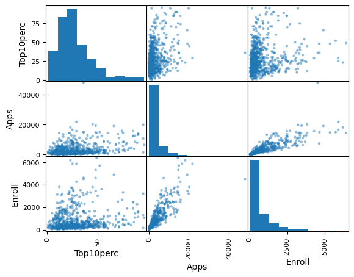

```python
columns = ["Top10perc", "Apps", "Enroll"]
pd.plotting.scatter_matrix(college[columns])
plt.show()
```

**Comment (d).** `Apps` and `Enroll` are strongly positively related, as expected since enrolment is bounded by applications, and the relationship is roughly linear with a few large state universities in the upper right. `Top10perc` has a weaker, positive but noisy relationship with both: colleges with many top-10 % students receive more applications, but there are many small selective colleges with few applications. The diagonal histograms confirm the right skew seen in (c).

**(e)** `Outstate` versus `Private`.

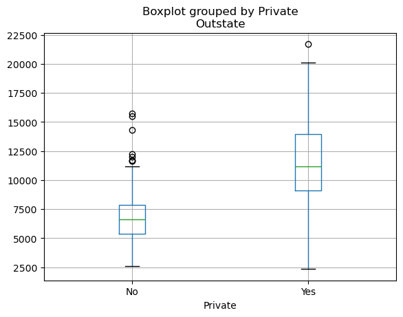

```python
college.boxplot(column='Outstate', by='Private')
plt.show()
```

**(f)** Elite universities: more than 50 % of new students from the top 10 % of their high school class.

```
Elite
No     699
Yes     78
Name: count, dtype: int64
```

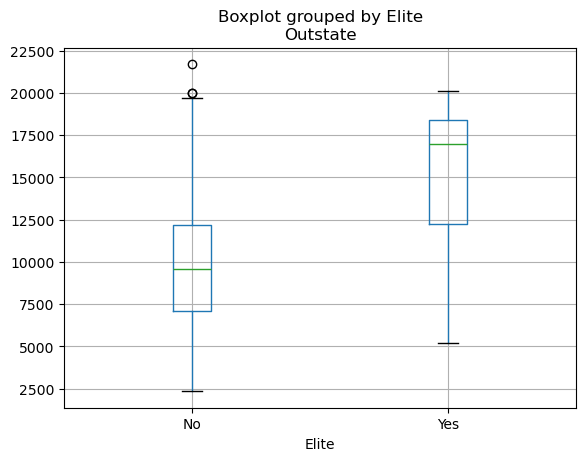

```python
# Top10perc is in percent (0-100), so the cut points are 50 and 100 rather than the book's 0.5 and 1
college['Elite'] = pd.cut(college['Top10perc'], [0, 50, 100], labels=['No', 'Yes'])
print(college['Elite'].value_counts())
college.boxplot(column='Outstate', by='Elite')
plt.show()
```

**(g)** Histograms with different numbers of bins.

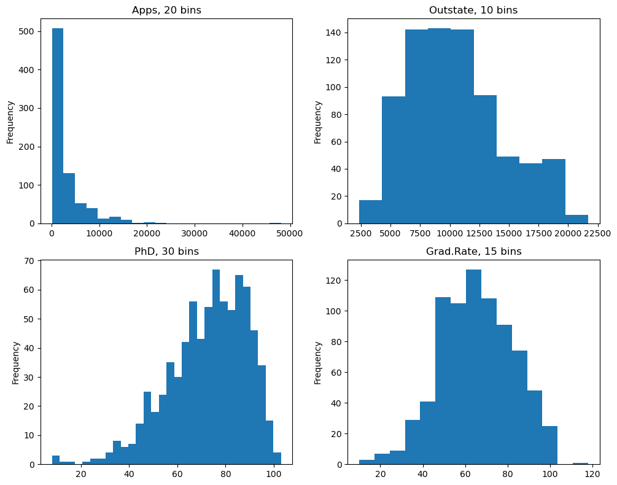

```python
fig, axes = plt.subplots(2, 2, figsize=(10, 8))

college['Apps'].plot.hist(bins=20, ax=axes[0, 0], title='Apps, 20 bins')
college['Outstate'].plot.hist(bins=10, ax=axes[0, 1], title='Outstate, 10 bins')
college['PhD'].plot.hist(bins=30, ax=axes[1, 0], title='PhD, 30 bins')
college['Grad.Rate'].plot.hist(bins=15, ax=axes[1, 1], title='Grad.Rate, 15 bins')

fig.tight_layout()
plt.show()
```

**Comment (g).** `Apps` is extremely right-skewed: most colleges receive fewer than 5 000 applications and a long tail reaches 48 000, so with 20 bins almost all mass sits in the first two. `Outstate` is roughly symmetric and bimodal-looking with 10 bins, reflecting the public/private split seen in (e). `PhD` is left-skewed with most colleges between 60 and 95 %. `Grad.Rate` is approximately symmetric around 65 % but the 15-bin histogram shows the impossible value above 100. Changing the number of bins mostly changes how much detail is visible; too few bins hide the bimodality of `Outstate`, too many make `Apps` look like a single spike.

**(h)** Further exploration.

```
Mean per group (Elite):
```

| Elite | No | Yes |
| --- | --- | --- |
| Apps | 2669.2 | 5980.6 |
| Accept | 1925.8 | 2852.6 |
| Enroll | 748.6 | 1060.7 |
| Top10perc | 23.1 | 67.6 |
| Top25perc | 51.9 | 91.1 |
| F.Undergrad | 3601.4 | 4582.7 |
| P.Undergrad | 914.5 | 324.9 |
| Outstate | 9904.2 | 15248.6 |
| Room.Board | 4248.3 | 5336.8 |
| Books | 544.3 | 594.9 |
| Personal | 1357.7 | 1188.2 |
| PhD | 70.8 | 89.3 |
| Terminal | 78.1 | 94.1 |
| S.F.Ratio | 14.5 | 10.6 |
| perc.alumni | 21.5 | 34.0 |
| Expend | 8684.4 | 18404.9 |
| Grad.Rate | 63.5 | 83.4 |

```
Median and mean of key variables:
```

| Elite | Outstate median | Outstate mean | Expend median | Expend mean | Grad.Rate median | Grad.Rate mean | S.F.Ratio median | S.F.Ratio mean | PhD median | PhD mean | perc.alumni median | perc.alumni mean |
| --- | --- | --- | --- | --- | --- | --- | --- | --- | --- | --- | --- | --- |
| No | 9556.0 | 9904.2 | 8086.0 | 8684.4 | 64.0 | 63.5 | 13.9 | 14.5 | 73.0 | 70.8 | 20.0 | 21.5 |
| Yes | 16950.0 | 15248.6 | 15944.0 | 18404.9 | 84.5 | 83.4 | 10.4 | 10.6 | 91.0 | 89.3 | 33.5 | 34.0 |

```
Acceptance rate by Elite:
```

| Elite | count | mean | std | min | 25% | 50% | 75% | max |
| --- | --- | --- | --- | --- | --- | --- | --- | --- |
| No | 699.0 | 0.770 | 0.122 | 0.328 | 0.701 | 0.788 | 0.855 | 1.00 |
| Yes | 78.0 | 0.543 | 0.193 | 0.154 | 0.415 | 0.533 | 0.696 | 0.96 |

```
Acceptance rate by Private:
```

| Private | count | mean | std | min | 25% | 50% | 75% | max |
| --- | --- | --- | --- | --- | --- | --- | --- | --- |
| No | 212.0 | 0.727 | 0.146 | 0.340 | 0.641 | 0.744 | 0.834 | 1.0 |
| Yes | 565.0 | 0.755 | 0.147 | 0.154 | 0.695 | 0.789 | 0.851 | 1.0 |

```
Number of colleges by Private x Elite:
```

| Elite Private | No | Yes |
| --- | --- | --- |
| No | 199 | 13 |
| Yes | 500 | 65 |

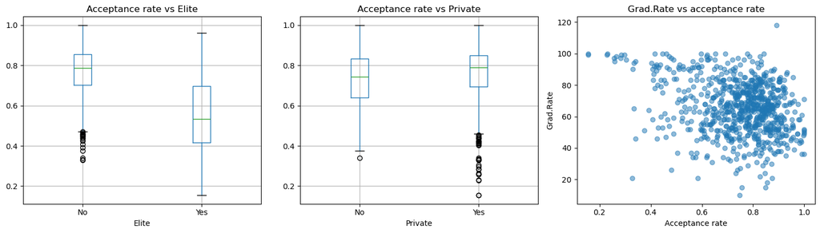

```
Correlation with Grad.Rate:
```

```
S.F.Ratio     -0.307
AcceptRate    -0.287
Personal      -0.269
P.Undergrad   -0.257
F.Undergrad   -0.079
Enroll        -0.022
Books          0.001
Accept         0.067
Apps           0.147
Terminal       0.290
PhD            0.305
Expend         0.390
Room.Board     0.425
Top25perc      0.477
perc.alumni    0.491
Top10perc      0.495
Outstate       0.571
Name: Grad.Rate, dtype: float64
```

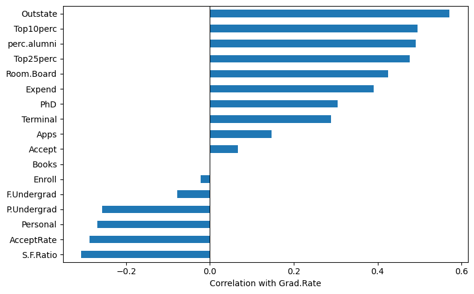

```
Colleges with Grad.Rate > 100:
```

| College | Private | Apps | Grad.Rate |
| --- | --- | --- | --- |
| Cazenovia College | Yes | 3847 | 118 |

```python
# Elite vs non-elite, acceptance rate and correlations

# 1. Elite vs non-elite: mean of every variable
print("Mean per group (Elite):")
display(college.groupby('Elite', observed=True).mean(numeric_only=True).T.round(1))

# 2. Median and mean of a few key variables
key_cols = ['Outstate', 'Expend', 'Grad.Rate', 'S.F.Ratio', 'PhD', 'perc.alumni']
print("Median and mean of key variables:")
display(college.groupby('Elite', observed=True)[key_cols].agg(['median', 'mean']).round(1))

# 3. Acceptance rate
college['AcceptRate'] = college['Accept'] / college['Apps']

print("Acceptance rate by Elite:")
display(college.groupby('Elite', observed=True)['AcceptRate'].describe().round(3))
print("Acceptance rate by Private:")
display(college.groupby('Private')['AcceptRate'].describe().round(3))
print("Number of colleges by Private x Elite:")
display(pd.crosstab(college['Private'], college['Elite']))

fig, axes = plt.subplots(1, 3, figsize=(15, 4.5))
college.boxplot(column='AcceptRate', by='Elite', ax=axes[0])
axes[0].set_title('Acceptance rate vs Elite')
college.boxplot(column='AcceptRate', by='Private', ax=axes[1])
axes[1].set_title('Acceptance rate vs Private')
axes[2].scatter(college['AcceptRate'], college['Grad.Rate'], alpha=0.5)
axes[2].set_xlabel('Acceptance rate')
axes[2].set_ylabel('Grad.Rate')
axes[2].set_title('Grad.Rate vs acceptance rate')
fig.suptitle('')
fig.tight_layout()
plt.show()

# 4. Correlation with Grad.Rate
corr_grad = college.corr(numeric_only=True)['Grad.Rate'].drop('Grad.Rate').sort_values()
print("Correlation with Grad.Rate:")
display(corr_grad.round(3))

fig, ax = plt.subplots(figsize=(8, 5))
corr_grad.plot.barh(ax=ax)
ax.set_xlabel('Correlation with Grad.Rate')
ax.axvline(0, color='black', linewidth=0.8)
fig.tight_layout()
plt.show()

# 5. Impossible values: Grad.Rate above 100 %
print("Colleges with Grad.Rate > 100:")
display(college.loc[college['Grad.Rate'] > 100, ['Private', 'Apps', 'Grad.Rate']])
```

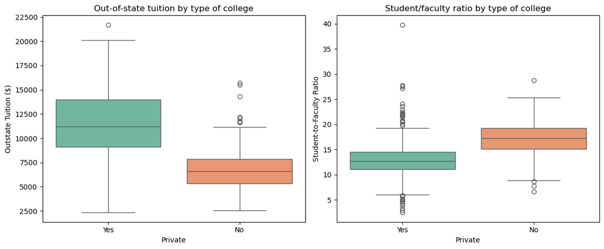

```python
# Outstate and S.F.Ratio by Private
plt.figure(figsize=(12, 5))

plt.subplot(1, 2, 1)
sns.boxplot(x='Private', y='Outstate', data=college, palette='Set2')
plt.title('Out-of-state tuition by type of college')
plt.xlabel('Private')
plt.ylabel('Outstate Tuition ($)')

plt.subplot(1, 2, 2)
sns.boxplot(x='Private', y='S.F.Ratio', data=college, palette='Set2')
plt.title('Student/faculty ratio by type of college')
plt.xlabel('Private')
plt.ylabel('Student-to-Faculty Ratio')

plt.tight_layout()
plt.show()
```

Correlation matrix over all numeric variables.

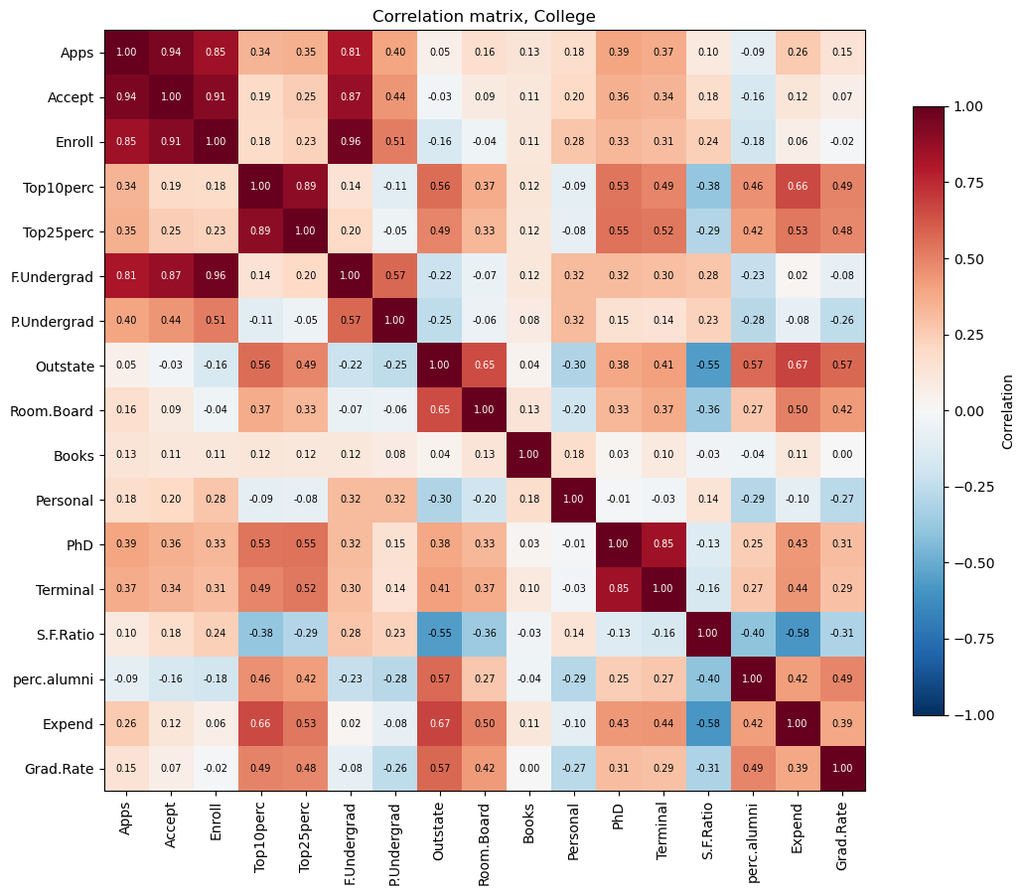

```
Strongest positive correlations:
```

```
Enroll     F.Undergrad    0.965
Apps       Accept         0.943
Accept     Enroll         0.912
Top10perc  Top25perc      0.892
Accept     F.Undergrad    0.874
PhD        Terminal       0.850
Apps       Enroll         0.847
           F.Undergrad    0.814
dtype: float64
```

```
Strongest negative correlations:
```

```
Room.Board  S.F.Ratio     -0.363
Top10perc   S.F.Ratio     -0.385
S.F.Ratio   perc.alumni   -0.403
Outstate    S.F.Ratio     -0.555
S.F.Ratio   Expend        -0.584
dtype: float64
```

```python
num_cols = ['Apps', 'Accept', 'Enroll', 'Top10perc', 'Top25perc', 'F.Undergrad', 'P.Undergrad',
            'Outstate', 'Room.Board', 'Books', 'Personal', 'PhD', 'Terminal', 'S.F.Ratio',
            'perc.alumni', 'Expend', 'Grad.Rate']
corr = corr_heatmap(college[num_cols], 'Correlation matrix, College')
strongest_pairs(corr)
```

**Summary of (h).**

### Exercise 10 – Boston

**(a)–(b)** Load the data. Each row is a suburb of Boston, each column a variable.

```python
Boston = load_data('Boston')
print(f'{Boston.shape[0]} rows (suburbs of Boston) and {Boston.shape[1]} columns (variables)')
Boston.columns
```

```
506 rows (suburbs of Boston) and 13 columns (variables)
```

```
Index(['crim', 'zn', 'indus', 'chas', 'nox', 'rm', 'age', 'dis', 'rad', 'tax',
       'ptratio', 'lstat', 'medv'],
      dtype='object')
```

**(c)** Pairwise relationships between the predictors.

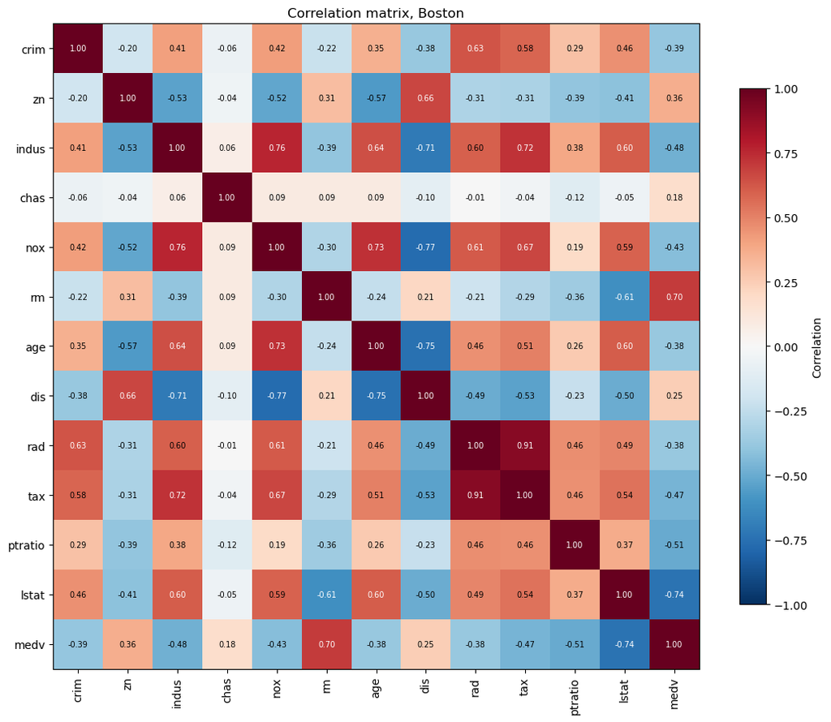

```python
corr = corr_heatmap(Boston, 'Correlation matrix, Boston')
```

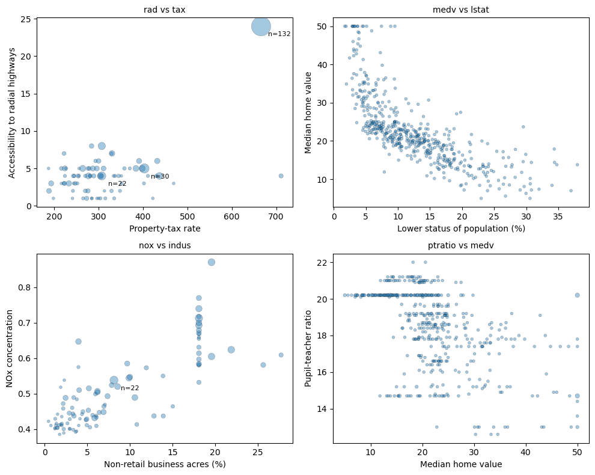

```python
# Point size = number of observations sharing the same (x, y); clusters with n >= 20 are labelled
fig, axes = plt.subplots(2, 2, figsize=(10, 8))
pairs = [
    ('tax', 'rad', 'Property-tax rate', 'Accessibility to radial highways'),
    ('lstat', 'medv', 'Lower status of population (%)', 'Median home value'),
    ('indus', 'nox', 'Non-retail business acres (%)', 'NOx concentration'),
    ('medv', 'ptratio', 'Median home value', 'Pupil-teacher ratio'),
]
for ax, (x, y, xlab, ylab) in zip(axes.ravel(), pairs):
    counts = Boston.groupby([x, y]).size().reset_index(name='n')
    ax.scatter(counts[x], counts[y], s=8 + 4*counts['n'], alpha=0.4,
               edgecolor='k', linewidth=0.3)
    for _, r in counts[counts['n'] >= 20].iterrows():
        ax.annotate(f"n={int(r['n'])}", (r[x], r[y]),
                    textcoords='offset points', xytext=(8, -12), fontsize=8)
    ax.set_xlabel(xlab); ax.set_ylabel(ylab)
    ax.set_title(f'{y} vs {x}', fontsize=10)
fig.tight_layout()
plt.show()
```

**Comment (c).** The correlation matrix and the scatterplots show a few strong structures. `rad` and `tax` are highly correlated (0.91), but the scatterplot reveals why: a single cluster of 132 suburbs shares the values `rad` = 24 and `tax` = 666, so the correlation is driven by one block of suburbs rather than by a smooth relationship. `medv` decreases with `lstat` in a clearly non-linear, convex way, and `medv` is censored at 50, visible as a row of points at the top. `nox` rises with `indus` up to about 18 % non-retail acres, where another large vertical cluster sits (`indus` = 18.1 is the same block of suburbs). `ptratio` shows a weak negative relationship with `medv`, and several horizontal bands appear because the ratio is set per town. Many variables are therefore shared by groups of suburbs, which produces repeated values and clusters rather than continuous clouds.

**(d)** Predictors associated with per capita crime rate.

```
Correlation with crime:
```

```
medv      -0.388
dis       -0.380
rm        -0.219
zn        -0.200
chas      -0.056
ptratio    0.290
age        0.353
indus      0.407
nox        0.421
lstat      0.456
tax        0.583
rad        0.626
Name: crim, dtype: float64
```

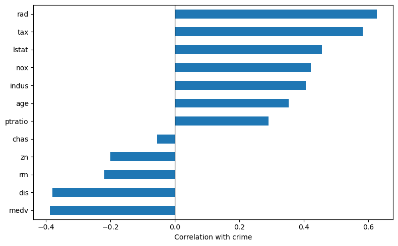

```python
corr_crime = Boston.corr()['crim'].drop('crim').sort_values()
print("Correlation with crime:")
display(corr_crime.round(3))

fig, ax = plt.subplots(figsize=(8, 5))
corr_crime.plot.barh(ax=ax)
ax.set_xlabel('Correlation with crime')
ax.axvline(0, color='black', linewidth=0.8)
fig.tight_layout()
plt.show()
```

**Comment (d).** Per capita crime is most strongly associated with `rad` (0.63) and `tax` (0.58): suburbs with high highway accessibility and high property-tax rates have more crime, but this is mostly the block of 132 suburbs with `rad` = 24 and `tax` = 666, which are also the ones with `indus` = 18.1. `lstat` (0.46), `nox` (0.42), `indus` (0.41) and `age` (0.35) are positively associated: older, more industrial, more polluted suburbs with a poorer population have more crime. `medv` (−0.39) and `dis` (−0.38) are negatively associated: crime is lower where homes are more valuable and further from the employment centres. The relationships are far from linear, since `crim` is extremely skewed (see (e)).

**(e)** Range of `crim`, `tax` and `ptratio`.

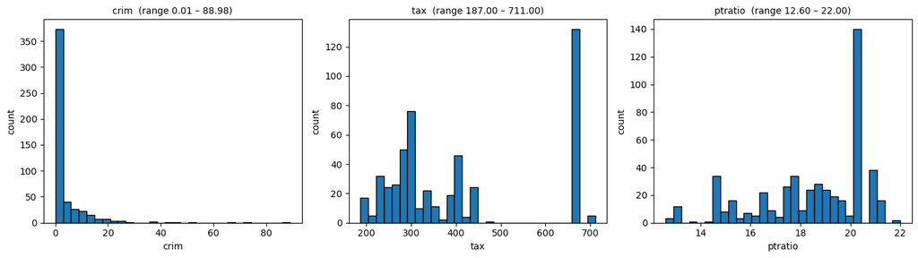

```
         crim     tax  ptratio
count  506.00  506.00   506.00
mean     3.61  408.24    18.46
std      8.60  168.54     2.16
min      0.01  187.00    12.60
25%      0.08  279.00    17.40
50%      0.26  330.00    19.05
75%      3.68  666.00    20.20
max     88.98  711.00    22.00
crim: range 0.01–88.98, median 0.26, mean 3.61, IQR outliers 66
tax: range 187.00–711.00, median 330.00, mean 408.24, IQR outliers 0
ptratio: range 12.60–22.00, median 19.05, mean 18.46, IQR outliers 0
```

```python
predictors = ['crim', 'tax', 'ptratio']
fig, axes = plt.subplots(1, 3, figsize=(14, 4))
for ax, col in zip(axes, predictors):
    ax.hist(Boston[col], bins=30, edgecolor='k')
    ax.set_title(f'{col}  (range {Boston[col].min():.2f} – {Boston[col].max():.2f})', fontsize=10)
    ax.set_xlabel(col); ax.set_ylabel('count')
fig.tight_layout()
plt.show()

print(Boston[predictors].describe().round(2))


for col in ['crim', 'tax', 'ptratio']:
    s = Boston[col]
    q1, q3 = s.quantile([0.25, 0.75]); hi = q3 + 1.5*(q3 - q1)
    print(f"{col}: range {s.min():.2f}–{s.max():.2f}, median {s.median():.2f}, "
          f"mean {s.mean():.2f}, IQR outliers {(s > hi).sum()}")
```

**Comment (e).** `crim` ranges from 0.006 to 88.98 with median 0.26 and mean 3.61, so the distribution is extremely right-skewed: half of the suburbs have essentially no crime, but 66 suburbs lie above the IQR outlier limit and a handful have rates above 40. `tax` ranges from 187 to 711 with a clear gap: the bulk lies between 187 and about 470, and then a block of suburbs sits at 666, which is why the histogram is bimodal and no point counts as an outlier. `ptratio` ranges from 12.6 to 22, is left-skewed with a large spike at 20.2, and has no outliers. So yes: some suburbs have particularly high crime rates, a large block has a high tax rate, and pupil-teacher ratios are high but within a narrow range.

**(f)–(h)** Charles river, median pupil-teacher ratio, suburb with lowest `medv`.

```python
# (f)
num_river = int(Boston['chas'].sum())
print(f'{num_river} suburbs bound the Charles River')

# (g)
print(f'Median pupil-teacher ratio: {Boston["ptratio"].median()}')

# (h) Suburb(s) with the lowest median home value, compared with the overall range
lowest_medv = Boston[Boston['medv'] == Boston['medv'].min()]
display(lowest_medv)
display(pd.concat([Boston.describe().loc[['min', '25%', '50%', '75%', 'max']],
                   lowest_medv.rename(index=lambda i: f'suburb {i}')]).round(2))
```

```
35 suburbs bound the Charles River
Median pupil-teacher ratio: 19.05
```

|  | crim | zn | indus | chas | nox | rm | age | dis | rad | tax | ptratio | lstat | medv |
| --- | --- | --- | --- | --- | --- | --- | --- | --- | --- | --- | --- | --- | --- |
| 398 | 38.3518 | 0.0 | 18.1 | 0 | 0.693 | 5.453 | 100.0 | 1.4896 | 24 | 666 | 20.2 | 30.59 | 5.0 |
| 405 | 67.9208 | 0.0 | 18.1 | 0 | 0.693 | 5.683 | 100.0 | 1.4254 | 24 | 666 | 20.2 | 22.98 | 5.0 |

|  | crim | zn | indus | chas | nox | rm | age | dis | rad | tax | ptratio | lstat | medv |
| --- | --- | --- | --- | --- | --- | --- | --- | --- | --- | --- | --- | --- | --- |
| min | 0.01 | 0.0 | 0.46 | 0.0 | 0.38 | 3.56 | 2.90 | 1.13 | 1.0 | 187.0 | 12.60 | 1.73 | 5.00 |
| 25% | 0.08 | 0.0 | 5.19 | 0.0 | 0.45 | 5.89 | 45.02 | 2.10 | 4.0 | 279.0 | 17.40 | 6.95 | 17.02 |
| 50% | 0.26 | 0.0 | 9.69 | 0.0 | 0.54 | 6.21 | 77.50 | 3.21 | 5.0 | 330.0 | 19.05 | 11.36 | 21.20 |
| 75% | 3.68 | 12.5 | 18.10 | 0.0 | 0.62 | 6.62 | 94.07 | 5.19 | 24.0 | 666.0 | 20.20 | 16.96 | 25.00 |
| max | 88.98 | 100.0 | 27.74 | 1.0 | 0.87 | 8.78 | 100.00 | 12.13 | 24.0 | 711.0 | 22.00 | 37.97 | 50.00 |
| suburb 398 | 38.35 | 0.0 | 18.10 | 0.0 | 0.69 | 5.45 | 100.00 | 1.49 | 24.0 | 666.0 | 20.20 | 30.59 | 5.00 |
| suburb 405 | 67.92 | 0.0 | 18.10 | 0.0 | 0.69 | 5.68 | 100.00 | 1.43 | 24.0 | 666.0 | 20.20 | 22.98 | 5.00 |

**(i)** Suburbs with more than seven / eight rooms per dwelling.

```python
# (i) "more than" seven / eight rooms per dwelling
rm_7 = Boston[Boston['rm'] > 7]
rm_8 = Boston[Boston['rm'] > 8]
print(f'Number of suburbs where the average number of rooms is more than:\n7: {len(rm_7)}\n8: {len(rm_8)}')
display(rm_8)
cmp = pd.DataFrame({
    'all (median)':    Boston.median(),
    'rm > 8 (median)': rm_8.median(),
    'difference':      rm_8.median() - Boston.median(),
}).round(2)
display(cmp)
```

```
Number of suburbs where the average number of rooms is more than:
7: 64
8: 13
```

|  | crim | zn | indus | chas | nox | rm | age | dis | rad | tax | ptratio | lstat | medv |
| --- | --- | --- | --- | --- | --- | --- | --- | --- | --- | --- | --- | --- | --- |
| 97 | 0.12083 | 0.0 | 2.89 | 0 | 0.4450 | 8.069 | 76.0 | 3.4952 | 2 | 276 | 18.0 | 4.21 | 38.7 |
| 163 | 1.51902 | 0.0 | 19.58 | 1 | 0.6050 | 8.375 | 93.9 | 2.1620 | 5 | 403 | 14.7 | 3.32 | 50.0 |
| 204 | 0.02009 | 95.0 | 2.68 | 0 | 0.4161 | 8.034 | 31.9 | 5.1180 | 4 | 224 | 14.7 | 2.88 | 50.0 |
| 224 | 0.31533 | 0.0 | 6.20 | 0 | 0.5040 | 8.266 | 78.3 | 2.8944 | 8 | 307 | 17.4 | 4.14 | 44.8 |
| 225 | 0.52693 | 0.0 | 6.20 | 0 | 0.5040 | 8.725 | 83.0 | 2.8944 | 8 | 307 | 17.4 | 4.63 | 50.0 |
| 226 | 0.38214 | 0.0 | 6.20 | 0 | 0.5040 | 8.040 | 86.5 | 3.2157 | 8 | 307 | 17.4 | 3.13 | 37.6 |
| 232 | 0.57529 | 0.0 | 6.20 | 0 | 0.5070 | 8.337 | 73.3 | 3.8384 | 8 | 307 | 17.4 | 2.47 | 41.7 |
| 233 | 0.33147 | 0.0 | 6.20 | 0 | 0.5070 | 8.247 | 70.4 | 3.6519 | 8 | 307 | 17.4 | 3.95 | 48.3 |
| 253 | 0.36894 | 22.0 | 5.86 | 0 | 0.4310 | 8.259 | 8.4 | 8.9067 | 7 | 330 | 19.1 | 3.54 | 42.8 |
| 257 | 0.61154 | 20.0 | 3.97 | 0 | 0.6470 | 8.704 | 86.9 | 1.8010 | 5 | 264 | 13.0 | 5.12 | 50.0 |
| 262 | 0.52014 | 20.0 | 3.97 | 0 | 0.6470 | 8.398 | 91.5 | 2.2885 | 5 | 264 | 13.0 | 5.91 | 48.8 |
| 267 | 0.57834 | 20.0 | 3.97 | 0 | 0.5750 | 8.297 | 67.0 | 2.4216 | 5 | 264 | 13.0 | 7.44 | 50.0 |
| 364 | 3.47428 | 0.0 | 18.10 | 1 | 0.7180 | 8.780 | 82.9 | 1.9047 | 24 | 666 | 20.2 | 5.29 | 21.9 |

|  | all (median) | rm > 8 (median) | difference |
| --- | --- | --- | --- |
| crim | 0.26 | 0.52 | 0.26 |
| zn | 0.00 | 0.00 | 0.00 |
| indus | 9.69 | 6.20 | -3.49 |
| chas | 0.00 | 0.00 | 0.00 |
| nox | 0.54 | 0.51 | -0.03 |
| rm | 6.21 | 8.30 | 2.09 |
| age | 77.50 | 78.30 | 0.80 |
| dis | 3.21 | 2.89 | -0.31 |
| rad | 5.00 | 7.00 | 2.00 |
| tax | 330.00 | 307.00 | -23.00 |
| ptratio | 19.05 | 17.40 | -1.65 |
| lstat | 11.36 | 4.14 | -7.22 |
| medv | 21.20 | 48.30 | 27.10 |

## Chapter 3

### Exercises: 1, 5, 8, 9

### Exercise 8 – Auto, simple linear regression

**(a)** `mpg` on `horsepower`.

```python
auto = load_data('Auto')
X = sm.add_constant(auto['horsepower'])
y = auto['mpg']
lin_reg = sm.OLS(y, X).fit()
print(lin_reg.summary())

b0, b1 = lin_reg.params['const'], lin_reg.params['horsepower']
print(f'Predicted mpg at horsepower = 98: {b0 + b1 * 98:.3f}')
```

```
                            OLS Regression Results
==============================================================================
Dep. Variable:                    mpg   R-squared:                       0.606
Model:                            OLS   Adj. R-squared:                  0.605
Method:                 Least Squares   F-statistic:                     599.7
Date:                Wed, 23 Sep 2026   Prob (F-statistic):           7.03e-81
Time:                        12:28:52   Log-Likelihood:                -1178.7
No. Observations:                 392   AIC:                             2361.
Df Residuals:                     390   BIC:                             2369.
Df Model:                           1
Covariance Type:            nonrobust
==============================================================================
                 coef    std err          t      P>|t|      [0.025      0.975]
------------------------------------------------------------------------------
const         39.9359      0.717     55.660      0.000      38.525      41.347
horsepower    -0.1578      0.006    -24.489      0.000      -0.171      -0.145
==============================================================================
Omnibus:                       16.432   Durbin-Watson:                   0.920
Prob(Omnibus):                  0.000   Jarque-Bera (JB):               17.305
Skew:                           0.492   Prob(JB):                     0.000175
Kurtosis:                       3.299   Cond. No.                         322.
==============================================================================

Notes:
[1] Standard Errors assume that the covariance matrix of the errors is correctly specified.
Predicted mpg at horsepower = 98: 24.467
```

**Comment (a).**

- *i.* Yes. The coefficient of `horsepower` has t = −24.5 and p-value < 0.0001, so the null hypothesis of no relationship is rejected. The F-statistic of 600 says the same thing.
- *ii.* The relationship is fairly strong: R² = 0.606, so horsepower alone explains about 61 % of the variance of `mpg`. The residual standard error is 4.9 mpg against a mean `mpg` of 23.4, about 21 %.
- *iii.* Negative. Each additional horsepower is associated with 0.158 fewer miles per gallon on average.
- *iv.* At `horsepower` = 98 the predicted `mpg` is 39.94 − 0.158 × 98 = 24.47. The intervals are computed in the next cell.

Confidence and prediction interval at `horsepower = 98`, computed by hand and checked against statsmodels.

```python
def get_residual_se(y_true, y_pred, df):
    # RSS = Sum of squared residual errors
    RSS = ((y_true - y_pred) ** 2).sum()
    s = (RSS / df) ** 0.5
    return s


def get_pred_se(x, x0, CI=True):
    n = len(x)
    x_mean = sum(x) / n
    s_xx = sum((x - x_mean) ** 2)

    if CI:
        inside = (1 / n) + ((x0 - x_mean) ** 2) / s_xx
    else:
        inside = (
            1 + (1 / n) + ((x0 - x_mean) ** 2) / s_xx
        )

    return inside**0.5


def get_CI(x0, ci_level, p, data, x_col, y_col, model):
    n = len(data)
    df = n - p
    alpha = 1 - ci_level

    y_0_hat = model.predict([1.0, x0])[0]
    t_crit = float(t.ppf(1 - alpha / 2, df=df))

    s = get_residual_se(data[y_col], model.fittedvalues, df)
    scale_factor = get_pred_se(data[x_col], x0, CI=True)

    margin = t_crit * s * scale_factor
    return [float(y_0_hat - margin), float(y_0_hat + margin)]


def get_PI(x0, ci_level, p, data, x_col, y_col, model):
    n = len(data)
    df = n - p
    alpha = 1 - ci_level

    y_0_hat = model.predict([1.0, x0])[0]
    t_crit = float(t.ppf(1 - alpha / 2, df=df))

    s = get_residual_se(data[y_col], model.fittedvalues, df)
    scale_factor = get_pred_se(data[x_col], x0, CI=False)

    margin = t_crit * s * scale_factor
    return [float(y_0_hat - margin), float(y_0_hat + margin)]


# Evaluate at horsepower = 98
x0 = 98
ci = get_CI(
    x0,
    ci_level=0.95,
    p=2,
    data=auto,
    x_col='horsepower',
    y_col='mpg',
    model=lin_reg,
)
pi = get_PI(
    x0,
    ci_level=0.95,
    p=2,
    data=auto,
    x_col='horsepower',
    y_col='mpg',
    model=lin_reg,
)

print(f'95% CI for x0={x0}: {ci}')
print(f'95% PI for x0={x0}: {pi}')

# Check against statsmodels
display(lin_reg.get_prediction(np.array([[1.0, x0]])).summary_frame(alpha=0.05).round(3))
```

```
95% CI for x0=98: [23.97307896070394, 24.961075344320914]
95% PI for x0=98: [14.80939607096712, 34.12475823405774]
```

|  | mean | mean_se | mean_ci_lower | mean_ci_upper | obs_ci_lower | obs_ci_upper |
| --- | --- | --- | --- | --- | --- | --- |
| 0 | 24.467 | 0.251 | 23.973 | 24.961 | 14.809 | 34.125 |

**(b)** Scatterplot with the least squares line.

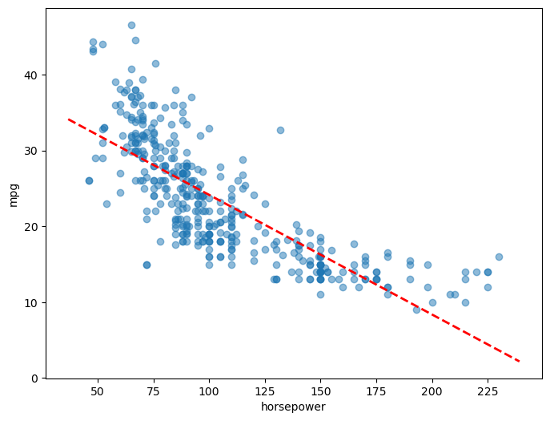

```python
def abline(ax, b, m, *args, **kwargs):
    "Add a line with slope m and intercept b to ax"
    xlim = ax.get_xlim()
    ylim = [m * xlim[0] + b, m * xlim[1] + b]
    ax.plot(xlim, ylim, *args, **kwargs)

fig, ax = plt.subplots(figsize=(8, 6))
ax.scatter(auto['horsepower'], auto['mpg'], alpha=0.5)
abline(ax, lin_reg.params['const'], lin_reg.params['horsepower'], 'r--', linewidth=2)
ax.set_xlabel('horsepower'); ax.set_ylabel('mpg')
plt.show()
```

**Comment (b).** The least squares line captures the downward trend, but the points are clearly curved around it: cars with very low and very high horsepower lie mostly above the line, and cars in the middle range (around 100 to 150 hp) lie mostly below it. A straight line is therefore not the right functional form; `mpg` decreases quickly at first and then flattens out.

**(c)** Diagnostic plots.

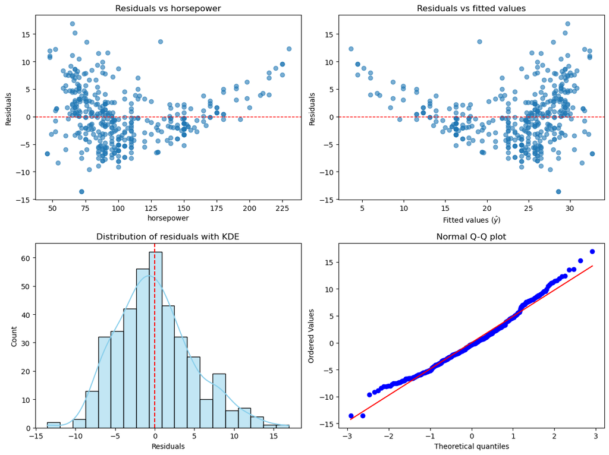

```python
# Diagnostic plots of the simple regression
resid = lin_reg.resid
fitted = lin_reg.fittedvalues

fig, axes = plt.subplots(2, 2, figsize=(12, 9))

ax = axes[0, 0]
ax.scatter(auto['horsepower'], resid, alpha=0.6)
ax.axhline(0, color='red', linestyle='--', linewidth=1)
ax.set(xlabel='horsepower', ylabel='Residuals', title='Residuals vs horsepower')

ax = axes[0, 1]
ax.scatter(fitted, resid, alpha=0.6)
ax.axhline(0, color='red', linestyle='--', linewidth=1)
ax.set(xlabel=r'Fitted values ($\hat{y}$)', ylabel='Residuals', title='Residuals vs fitted values')

ax = axes[1, 0]
sns.histplot(resid, kde=True, ax=ax, color='skyblue', edgecolor='black')
ax.axvline(0, color='red', linestyle='--', linewidth=1.5)
ax.set(xlabel='Residuals', ylabel='Count', title='Distribution of residuals with KDE')

ax = axes[1, 1]
stats.probplot(resid, dist='norm', plot=ax)
ax.set_title('Normal Q-Q plot')

fig.tight_layout()
plt.show()
```

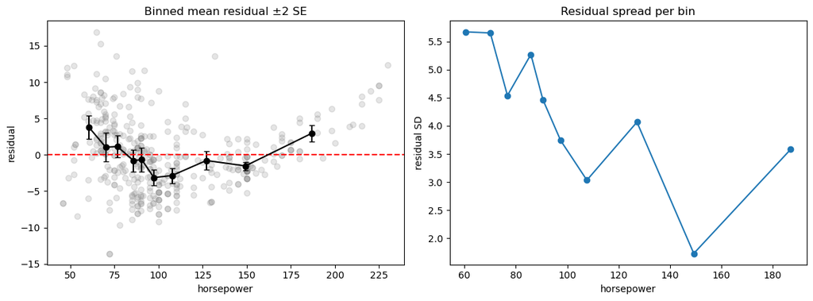

```python
# Binned residuals: is the mean residual zero and the spread constant across horsepower?
x = auto['horsepower']
bins = pd.qcut(x, 10)
g = resid.groupby(bins, observed=True)
summ = pd.DataFrame({'center': x.groupby(bins, observed=True).mean(),
                     'mean': g.mean(), 'sd': g.std(), 'n': g.size()})
summ['se'] = summ['sd'] / np.sqrt(summ['n'])

fig, axes = plt.subplots(1, 2, figsize=(12, 4.5))
axes[0].scatter(x, resid, alpha=0.2, color='grey')
axes[0].errorbar(summ['center'], summ['mean'], yerr=2*summ['se'], fmt='o-', color='k', capsize=3)
axes[0].axhline(0, color='r', ls='--')
axes[0].set(xlabel='horsepower', ylabel='residual', title='Binned mean residual ±2 SE')
axes[1].plot(summ['center'], summ['sd'], 'o-')
axes[1].set(xlabel='horsepower', ylabel='residual SD', title='Residual spread per bin')
fig.tight_layout(); plt.show()
```

The Durbin-Watson statistic of 0.92 also indicates positive autocorrelation, but this reflects the ordering of the data (cars are roughly sorted by year and make) rather than a time series problem.

### Exercise 9 – Auto, multiple linear regression

**(a)–(b)** Scatterplot matrix and correlation matrix.

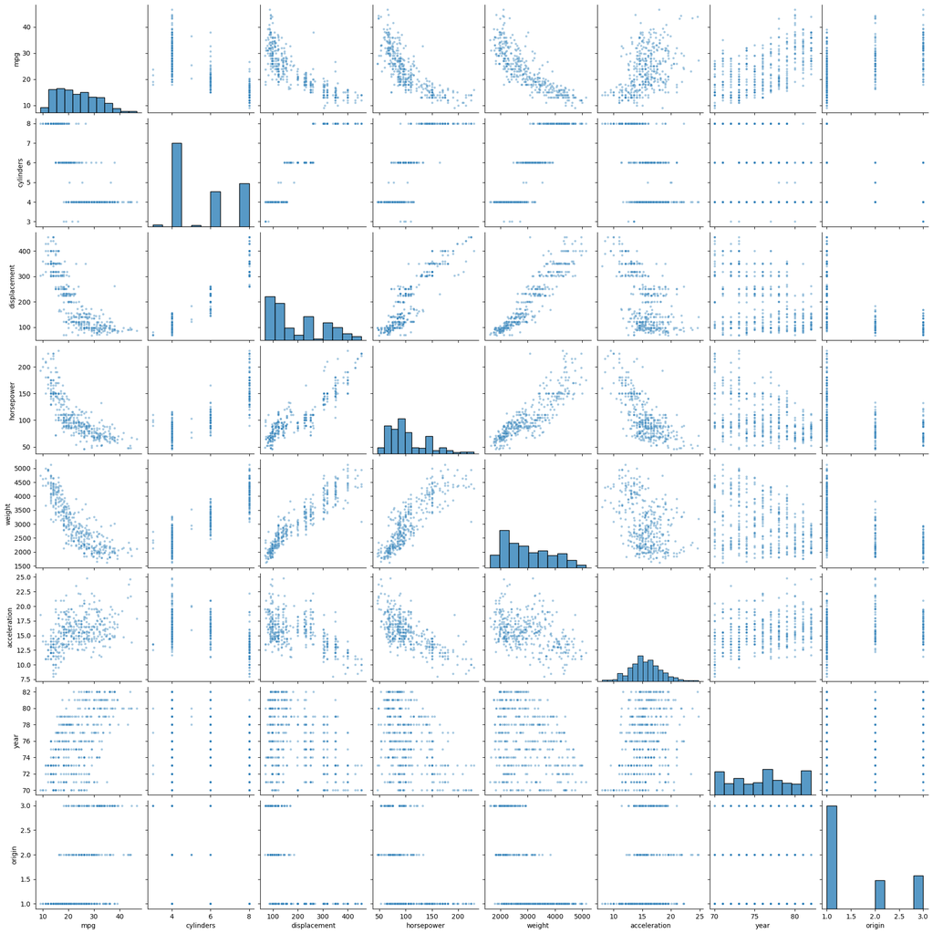

|  | mpg | cylinders | displacement | horsepower | weight | acceleration | year | origin |
| --- | --- | --- | --- | --- | --- | --- | --- | --- |
| mpg | 1.00 | -0.78 | -0.81 | -0.78 | -0.83 | 0.42 | 0.58 | 0.57 |
| cylinders | -0.78 | 1.00 | 0.95 | 0.84 | 0.90 | -0.50 | -0.35 | -0.57 |
| displacement | -0.81 | 0.95 | 1.00 | 0.90 | 0.93 | -0.54 | -0.37 | -0.61 |
| horsepower | -0.78 | 0.84 | 0.90 | 1.00 | 0.86 | -0.69 | -0.42 | -0.46 |
| weight | -0.83 | 0.90 | 0.93 | 0.86 | 1.00 | -0.42 | -0.31 | -0.59 |
| acceleration | 0.42 | -0.50 | -0.54 | -0.69 | -0.42 | 1.00 | 0.29 | 0.21 |
| year | 0.58 | -0.35 | -0.37 | -0.42 | -0.31 | 0.29 | 1.00 | 0.18 |
| origin | 0.57 | -0.57 | -0.61 | -0.46 | -0.59 | 0.21 | 0.18 | 1.00 |

```python
sns.pairplot(auto.select_dtypes('number'), plot_kws={'alpha': 0.4, 's': 12}, diag_kind='hist')
plt.show()

auto.select_dtypes('number').corr().round(2)
```

**Comment (a)–(b).** `mpg` is strongly negatively correlated with `weight` (−0.83), `displacement` (−0.81), `cylinders` (−0.78) and `horsepower` (−0.78), and positively with `year` (0.58), `origin` (0.57) and `acceleration` (0.42). The scatterplot matrix shows that all four negative relationships are curved, as in Exercise 8. The four engine-size variables are also very strongly correlated with each other, from 0.84 to 0.95, so they carry almost the same information and multicollinearity is to be expected in the multiple regression. `cylinders`, `year` and `origin` are discrete and appear as vertical bands.

**(c)** `mpg` on all other variables except `name`.

```python
# name is the row index, so dropping mpg leaves all other variables as predictors
X = sm.add_constant(auto.drop(columns='mpg'))
y = auto['mpg']
results = sm.OLS(y, X).fit()
print(results.summary())

# F-test for H0: all slopes are zero (relationship between predictors and response)
print(f'F = {results.fvalue:.2f}, p = {results.f_pvalue:.2e}')
```

```
                            OLS Regression Results
==============================================================================
Dep. Variable:                    mpg   R-squared:                       0.821
Model:                            OLS   Adj. R-squared:                  0.818
Method:                 Least Squares   F-statistic:                     252.4
Date:                Wed, 23 Sep 2026   Prob (F-statistic):          2.04e-139
Time:                        12:28:54   Log-Likelihood:                -1023.5
No. Observations:                 392   AIC:                             2063.
Df Residuals:                     384   BIC:                             2095.
Df Model:                           7
Covariance Type:            nonrobust
================================================================================
                   coef    std err          t      P>|t|      [0.025      0.975]
--------------------------------------------------------------------------------
const          -17.2184      4.644     -3.707      0.000     -26.350      -8.087
cylinders       -0.4934      0.323     -1.526      0.128      -1.129       0.142
displacement     0.0199      0.008      2.647      0.008       0.005       0.035
horsepower      -0.0170      0.014     -1.230      0.220      -0.044       0.010
weight          -0.0065      0.001     -9.929      0.000      -0.008      -0.005
acceleration     0.0806      0.099      0.815      0.415      -0.114       0.275
year             0.7508      0.051     14.729      0.000       0.651       0.851
origin           1.4261      0.278      5.127      0.000       0.879       1.973
==============================================================================
Omnibus:                       31.906   Durbin-Watson:                   1.309
Prob(Omnibus):                  0.000   Jarque-Bera (JB):               53.100
Skew:                           0.529   Prob(JB):                     2.95e-12
Kurtosis:                       4.460   Cond. No.                     8.59e+04
==============================================================================

Notes:
[1] Standard Errors assume that the covariance matrix of the errors is correctly specified.
[2] The condition number is large, 8.59e+04. This might indicate that there are
strong multicollinearity or other numerical problems.
F = 252.43, p = 2.04e-139
```

**Comment (c).**

- *i.* Yes. The F-statistic is 252 with p-value 2 × 10⁻¹³⁹, so at least one predictor is related to `mpg`. The model explains 82 % of the variance (R² = 0.821), a large improvement over the 61 % from `horsepower` alone.
- *ii.* `weight` (p < 0.001), `year` (p < 0.001), `origin` (p < 0.001) and `displacement` (p = 0.008) are statistically significant. `cylinders`, `horsepower` and `acceleration` are not, although `horsepower` was highly significant on its own. This is the multicollinearity seen in (b): once `weight` and `displacement` are in the model, `horsepower` and `cylinders` add little independent information, which is also flagged by the large condition number. The sign of `displacement` is even positive, which should not be interpreted causally.
- *iii.* The coefficient of `year` is 0.75: holding the other variables fixed, each model year is associated with 0.75 more miles per gallon, so fuel efficiency improved by about 7.5 mpg over the decade 1970 to 1982 for cars of the same size and power. `origin` is coded 1 = American, 2 = European, 3 = Japanese and is treated as numeric here; its coefficient of 1.43 says that European and Japanese cars get more mpg than American cars of the same specification.

**(d)** Diagnostic plots (the four plots of R's `plot(lm)`).

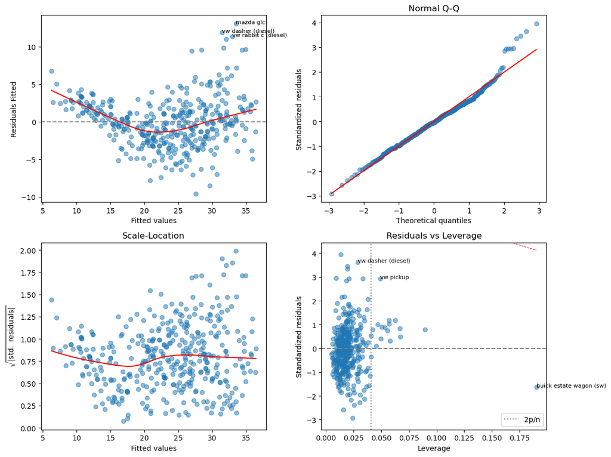

```python
def diagnostic_plots(results, n_label=3):
    """The four plots of R's plot(lm) for a fitted statsmodels OLS result."""
    infl = results.get_influence()
    fitted, resid = results.fittedvalues, results.resid
    std_resid = infl.resid_studentized_internal
    leverage, cooks = infl.hat_matrix_diag, infl.cooks_distance[0]
    p, n = results.df_model + 1, len(resid)
    idx = results.model.data.row_labels
    fig, axes = plt.subplots(2, 2, figsize=(12, 9))

    # 1. Residuals vs fitted: curvature = wrong functional form
    ax = axes[0, 0]
    ax.scatter(fitted, resid, alpha=0.5)
    s = lowess(resid, fitted, frac=0.6); ax.plot(s[:, 0], s[:, 1], 'r-')
    ax.axhline(0, color='grey', ls='--')
    ax.set(xlabel='Fitted values', ylabel='Residuals Fitted')
    for i in np.argsort(np.abs(resid.values))[-n_label:]:
        ax.annotate(idx[i], (fitted.iloc[i], resid.iloc[i]), fontsize=8)

    # 2. Normal Q-Q of standardized residuals
    ax = axes[0, 1]
    (osm, osr), (slope, intercept, _) = stats.probplot(std_resid, dist='norm')
    ax.scatter(osm, osr, alpha=0.5); ax.plot(osm, slope*osm + intercept, 'r-')
    ax.set(xlabel='Theoretical quantiles', ylabel='Standardized residuals', title='Normal Q-Q')

    # 3. Scale-location: trend = non-constant v
    ax = axes[1, 0]
    sqrt_abs = np.sqrt(np.abs(std_resid))
    ax.scatter(fitted, sqrt_abs, alpha=0.5)
    s = lowess(sqrt_abs, fitted, frac=0.6); ax.plot(s[:, 0], s[:, 1], 'r-')
    ax.set(xlabel='Fitted values', ylabel=r'$\sqrt{|\mathrm{std.\ residuals}|}$', title='Scale-Location')

    # 4. Residuals vs leverage with Cook's distance contours
    ax = axes[1, 1]
    ax.scatter(leverage, std_resid, alpha=0.5)
    ax.axhline(0, color='grey', ls='--')
    ax.axvline(2*p/n, color='grey', ls=':', label='2p/n')
    lev = np.linspace(leverage.min(), leverage.max(), 100)
    for d in (0.5, 1.0):
        for sign in (1, -1):
            ax.plot(lev, sign*np.sqrt(d*p*(1 - lev)/lev), 'r--', lw=0.8)
    ax.set_ylim(std_resid.min() - 0.5, std_resid.max() + 0.5)
    ax.set(xlabel='Leverage', ylabel='Standardized residuals', title="Residuals vs Leverage")
    for i in np.argsort(cooks)[-n_label:]:
        ax.annotate(idx[i], (leverage[i], std_resid[i]), fontsize=8)
    ax.legend()
    fig.tight_layout()
    return fig

diagnostic_plots(results)
plt.show()
```

**(e)** Interaction effects.

```python
# Interaction terms added one at a time to the full model
base = 'mpg ~ cylinders + displacement + horsepower + weight + acceleration + year + origin'
for inter in ['horsepower:weight', 'displacement:horsepower', 'horsepower:year',
              'weight:year', 'cylinders:displacement', 'year:origin']:
    m = ols(base + ' + ' + inter, auto).fit()
    print(f'{inter:24s} coef={m.params[inter]: .3e}  p={m.pvalues[inter]:.1e}  adjR2={m.rsquared_adj:.4f}')

m_hw = ols('mpg ~ horsepower * weight + year + origin', auto).fit()
print(m_hw.summary())
```

```
horsepower:weight        coef= 5.529e-05  p=4.1e-23  adjR2=0.8590
displacement:horsepower  coef= 5.236e-04  p=3.4e-24  adjR2=0.8608
horsepower:year          coef=-1.139e-02  p=6.7e-17  adjR2=0.8481
weight:year              coef=-4.879e-04  p=1.5e-14  adjR2=0.8439
cylinders:displacement   coef= 1.361e-02  p=2.8e-14  adjR2=0.8433
year:origin              coef= 1.989e-01  p=1.1e-03  adjR2=0.8228
                            OLS Regression Results
==============================================================================
Dep. Variable:                    mpg   R-squared:                       0.861
Model:                            OLS   Adj. R-squared:                  0.859
Method:                 Least Squares   F-statistic:                     477.5
Date:                Wed, 23 Sep 2026   Prob (F-statistic):          8.32e-163
Time:                        12:28:55   Log-Likelihood:                -974.68
No. Observations:                 392   AIC:                             1961.
Df Residuals:                     386   BIC:                             1985.
Df Model:                           5
Covariance Type:            nonrobust
=====================================================================================
                        coef    std err          t      P>|t|      [0.025      0.975]
-------------------------------------------------------------------------------------
Intercept             0.8145      3.969      0.205      0.838      -6.990       8.619
horsepower           -0.2160      0.021    -10.514      0.000      -0.256      -0.176
weight               -0.0111      0.001    -17.435      0.000      -0.012      -0.010
horsepower:weight  5.501e-05   5.05e-06     10.891      0.000    4.51e-05    6.49e-05
year                  0.7677      0.045     17.195      0.000       0.680       0.855
origin                0.7224      0.233      3.103      0.002       0.265       1.180
==============================================================================
Omnibus:                       40.135   Durbin-Watson:                   1.451
Prob(Omnibus):                  0.000   Jarque-Bera (JB):               69.958
Skew:                           0.627   Prob(JB):                     6.44e-16
Kurtosis:                       4.646   Cond. No.                     1.08e+07
==============================================================================

Notes:
[1] Standard Errors assume that the covariance matrix of the errors is correctly specified.
[2] The condition number is large, 1.08e+07. This might indicate that there are
strong multicollinearity or other numerical problems.
```

**Comment (e).** Every interaction tried is statistically significant, which is not surprising with 392 observations. The two most useful are `horsepower:weight` and `displacement:horsepower`, which each raise the adjusted R² from 0.818 to about 0.86. In the model `mpg ~ horsepower * weight + year + origin` all terms are significant, and the interaction coefficient is positive (5.5 × 10⁻⁵, p < 0.001): the penalty of extra horsepower on `mpg` is smaller for heavy cars than for light cars, or equivalently the effect of weight is weaker for powerful cars. This model with five terms has a higher adjusted R² (0.859) than the full additive model with seven predictors, and it drops the collinear `cylinders`, `displacement` and `acceleration`. The residuals remain right-skewed, so the interaction does not remove the non-linearity completely.

**(f)** Transformations of the variables.

```python
# Transformations of the variables: adjusted R^2 and Breusch-Pagan test for non-constant variance
models = {
  'base':        base,
  'hp^2':        base.replace('horsepower', 'horsepower + I(horsepower**2)'),
  'log(hp)':     base.replace('horsepower', 'np.log(horsepower)'),
  'sqrt(hp)':    base.replace('horsepower', 'np.sqrt(horsepower)'),
  'log(mpg)':    'np.log(mpg) ~ cylinders + displacement + horsepower + weight + acceleration + year + origin',
  'log-log':     'np.log(mpg) ~ cylinders + displacement + np.log(horsepower) + np.log(weight) + acceleration + year + origin',
}
for name, f in models.items():
    m = ols(f, auto).fit()
    print(f'{name:10s} adjR2={m.rsquared_adj:.4f}  BP p={het_breuschpagan(m.resid, m.model.exog)[1]:.1e}')
```

```
base       adjR2=0.8182  BP p=1.2e-04
hp^2       adjR2=0.8522  BP p=4.5e-06
log(hp)    adjR2=0.8340  BP p=2.4e-05
sqrt(hp)   adjR2=0.8237  BP p=1.1e-04
log(mpg)   adjR2=0.8773  BP p=9.2e-02
log-log    adjR2=0.8885  BP p=1.3e-01
```

**Comment (f).** Transforming `horsepower` improves the fit: a quadratic term raises the adjusted R² from 0.818 to 0.852, log(`horsepower`) to 0.834 and the square root to 0.824. All of these still fail the Breusch-Pagan test (p < 0.001), so the variance of the residuals remains non-constant. Transforming the response works better: log(`mpg`) gives adjusted R² 0.877 and a Breusch-Pagan p-value of 0.09, and the log-log model with log(`horsepower`) and log(`weight`) gives the best fit, adjusted R² 0.889, with p = 0.13 for the Breusch-Pagan test, so heteroscedasticity is no longer detected. The log transformation of `mpg` makes sense physically, since fuel consumption per mile (1/mpg) is closer to proportional to weight and power, and it turns the multiplicative relationship into an additive one. The recommended model is therefore log(`mpg`) on log(`horsepower`), log(`weight`), `year` and `origin`.

## Additional coding task: bias-variance trade-off

### Setup

The ground truth is $$ f(x) = \sin(2x_1), \qquad y = f(x) + \varepsilon, \qquad \varepsilon \sim \mathcal{N}(0, \sigma^2),\ \sigma = 0.5 . $$ There are $p$ predictors $x = (x_1, \dots, x_p)$, each drawn independently from $\mathcal{U}(-1, 1)$, but only $x_1$ carries information about $y$; the remaining $p - 1$ predictors are pure noise. We use a fixed design with $n_{\text{train}} = 50$ training points and $n_{\text{test}} = 500$ noise-free test points $\{(x_0, f(x_0))\}$, and vary $p \in \{1, 2, 3, 4, 10, 20\}$.

Two estimators $\hat f$ are compared:

- **Linear regression** $\hat f(x) = \hat\beta_0 + \sum_{j=1}^p \hat\beta_j x_j$, fitted by least squares.
- **KNN regression** $\hat f(x_0) = \frac{1}{K}\sum_{i \in N_K(x_0)} y_i$, where $N_K(x_0)$ are the $K$ training points closest to $x_0$ in Euclidean distance over all $p$ predictors, for $K = 1, \dots, 9$.

### Bias-variance decomposition

For a fixed test point $x_0$ and a training set $\mathcal{D}$ (here: fixed $X$, random noise $\varepsilon$), the expected squared error of $\hat f$ against the *true* function decomposes as $$ \mathbb{E}_{\mathcal{D}}\Big[\big(f(x_0) - \hat f(x_0; \mathcal{D})\big)^2\Big] = \underbrace{\big(f(x_0) - \mathbb{E}_{\mathcal{D}}[\hat f(x_0)]\big)^2}_{\text{Bias}^2(x_0)} + \underbrace{\mathbb{E}_{\mathcal{D}}\Big[\big(\hat f(x_0) - \mathbb{E}_{\mathcal{D}}[\hat f(x_0)]\big)^2\Big]}_{\text{Var}(x_0)} . $$ The cross term vanishes because $\mathbb{E}_{\mathcal{D}}\big[\hat f(x_0) - \mathbb{E}_{\mathcal{D}}[\hat f(x_0)]\big] = 0$. If the test response were observed with noise, the irreducible error $\sigma^2 = 0.25$ would be added; since we compare with $f(x_0)$ directly it is left out, so $\text{MSE} = \text{Bias}^2 + \text{Var}$ holds exactly.

### Monte Carlo estimation

The expectation over $\mathcal{D}$ is approximated by drawing $L = 100$ independent noise vectors $\varepsilon^{(l)}$, refitting the model on $y^{(l)} = f(X) + \varepsilon^{(l)}$ each time, and predicting at every test point. Writing $\hat f^{(l)}(x_0)$ for the prediction from replication $l$, $$ \bar f(x_0) = \frac{1}{L}\sum_{l=1}^{L} \hat f^{(l)}(x_0) $$ estimates $\mathbb{E}_{\mathcal{D}}[\hat f(x_0)]$. Averaging over the $n_{\text{test}}$ test points gives the three reported quantities: $$ \widehat{\text{Bias}^2} = \frac{1}{n_{\text{test}}} \sum_{x_0} \big(f(x_0) - \bar f(x_0)\big)^2, \qquad \widehat{\text{Var}} = \frac{1}{n_{\text{test}}} \sum_{x_0} \frac{1}{L}\sum_{l=1}^{L} \big(\hat f^{(l)}(x_0) - \bar f(x_0)\big)^2, \qquad \widehat{\text{MSE}} = \frac{1}{n_{\text{test}}} \sum_{x_0} \frac{1}{L}\sum_{l=1}^{L} \big(\hat f^{(l)}(x_0) - f(x_0)\big)^2 . $$ In the code, `yhat_lm` and `yhat_knn[:, :, j]` are the $n_{\text{test}} \times L$ matrices of $\hat f^{(l)}(x_0)$, `ybar_*` is $\bar f(x_0)$, `biasSQ_*`, `variance_*` and `err_*` are the three estimates above, and the results are collected in `out_lm` (one row per $p$) and `out_knn` (one row per $(p, K)$).

### What to expect

- **KNN, effect of $K$.** Small $K$ averages few noisy responses, so $\text{Var} \approx \sigma^2 / K$ is large and the bias is small: a flexible fit. Large $K$ averages over a wide neighbourhood in which $f$ is not constant, so the bias grows while the variance shrinks. The MSE is U-shaped in $1/K$.
- **KNN, effect of $p$.** With more noise predictors the Euclidean distance is dominated by irrelevant coordinates, so the $K$ nearest neighbours are no longer close in $x_1$ and the local average is taken over points with very different $f$ values. This inflates the bias for every $K$: the curse of dimensionality.
- **Linear regression.** $\hat f$ is linear but $f$ is a sine, so there is a model bias that does not depend on $p$. Each noise predictor adds one coefficient estimated from 50 points, so the variance grows roughly linearly in $p$, approximately $\sigma^2 (p+1)/n_{\text{train}}$.
- The MSE pattern should resemble FIGURE 3.20 in the book: KNN is competitive for $p \le 2$ and linear regression wins for larger $p$.

```python
import numpy as np
import pandas as pd
from sklearn.neighbors import KNeighborsRegressor
from sklearn.linear_model import LinearRegression

ntrain = 50  # Training
ntest = 500  # Test
nrep = 100  # Repeat 100 times
p = 20
puse = np.array([1, 2, 3, 4, 10, 20])  # Number of predictors
k = np.arange(1, 10)

sigma = 0.5
np.random.seed(0)
Xtrain = np.random.uniform(-1, 1, [ntrain, p])
Xtest = np.random.uniform(-1, 1, [ntest, p])
y0 = np.sin(2 * Xtrain[:, 0])  # Only the first predictor is related to y
ytest = np.sin(2 * Xtest[:, 0])

out_knn = pd.DataFrame()  # Output results
out_lm = pd.DataFrame()

for i in range(len(puse)):
    yhat_lm = np.zeros((ntest, nrep))
    yhat_knn = np.zeros((ntest, nrep, len(k)))

    for l in range(nrep):
        y = y0 + np.random.normal(0, sigma, ntrain)

        ######### DO: fit linear regression using LinearRegression funciton, assign predicted value to yhat_lm[:, [l]] #########
        fit_lm = LinearRegression().fit(Xtrain[:, :puse[i]], y)
        yhat_lm[:, l] =  fit_lm.predict(Xtest[:, :puse[i]])

        for j in range(len(k)):

            ######### DO: fit knn using KNeighborsRegressor funciton, assign predicted value to yhat_knn[:, l, j] #########
            fit_knn = KNeighborsRegressor(k[j]).fit(Xtrain[:, :puse[i]], y)
            yhat_knn[:, l, j] = fit_knn.predict(Xtest[:, :puse[i]])


        #print(i + 1, "-th p, ", l + 1, "-th repetition finished. \n")


    ######### DO: compute bias and variance of linear regression #########

    # Compute mean of predicted values
    ybar_lm = yhat_lm.mean(axis=1)

    # Compute bias^2
    biasSQ_lm = np.mean((ytest - ybar_lm)**2)

    # Compute variance
    variance_lm = np.mean((yhat_lm - ybar_lm[:, None])**2)

    # Compute total MSE
    err_lm = np.mean((yhat_lm - ytest[:, None])**2)

    out_lm = pd.concat([out_lm, pd.DataFrame({'biasSQ_lm': [biasSQ_lm], 'variance_lm': [variance_lm], 'MSE': [err_lm], 'p': [puse[i]]})])
    out_lm = out_lm.reset_index(drop=True)

    ######### DO: compute bias and variance of knn regression #########
    for j in range(len(k)):
        yh = yhat_knn[:, :, j]
        # Compute mean of predicted values
        ybar_knn = yh.mean(axis=1)

        # Compute bias^2
        biasSQ_knn = np.mean((ytest - ybar_knn)**2)


        # Compute variance
        variance_knn = np.mean((yh - ybar_knn[:, None])**2)

        # Compute total MSE
        err_knn = np.mean((yh - ytest[:, None])**2)

        out_knn = pd.concat([out_knn, pd.DataFrame({'biasSQ_knn': [biasSQ_knn], 'variance_knn': [variance_knn], 'MSE': [err_knn], '1/K': [1 / k[j]], 'p': [puse[i]]})])
        out_knn = out_knn.reset_index(drop=True)
```

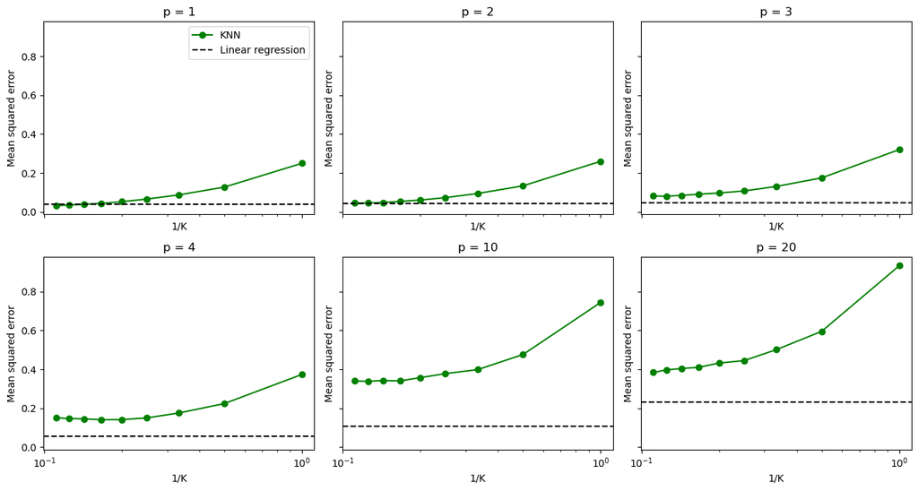

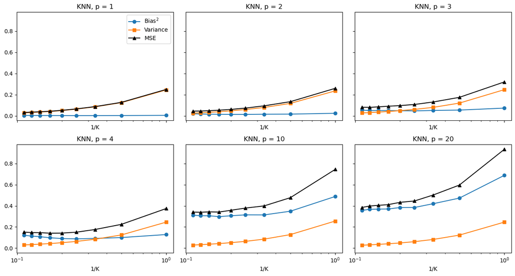

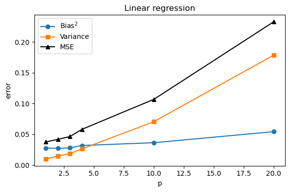

```python
fig, axes = plt.subplots(2, 3, figsize=(13, 7), sharex=True, sharey=True)
for ax, pv in zip(axes.ravel(), puse):
    d = out_knn[out_knn['p'] == pv].sort_values('1/K')
    lm = out_lm.loc[out_lm['p'] == pv, 'MSE'].iloc[0]
    ax.plot(d['1/K'], d['MSE'], 'o-', color='green', label='KNN')
    ax.axhline(lm, color='k', ls='--', label='Linear regression')
    ax.set_xscale('log'); ax.set_title(f'p = {pv}')
    ax.set_xlabel('1/K'); ax.set_ylabel('Mean squared error')
axes[0, 0].legend(); fig.tight_layout(); plt.show()


fig, axes = plt.subplots(2, 3, figsize=(13, 7), sharex=True, sharey=True)
for ax, pv in zip(axes.ravel(), puse):
    d = out_knn[out_knn['p'] == pv].sort_values('1/K')
    ax.plot(d['1/K'], d['biasSQ_knn'], 'o-', label='Bias$^2$')
    ax.plot(d['1/K'], d['variance_knn'], 's-', label='Variance')
    ax.plot(d['1/K'], d['MSE'], 'k^-', label='MSE')
    ax.set_xscale('log'); ax.set_title(f'KNN, p = {pv}'); ax.set_xlabel('1/K')
axes[0, 0].legend(); fig.tight_layout(); plt.show()


fig, ax = plt.subplots(figsize=(6, 4))
ax.plot(out_lm['p'], out_lm['biasSQ_lm'], 'o-', label='Bias$^2$')
ax.plot(out_lm['p'], out_lm['variance_lm'], 's-', label='Variance')
ax.plot(out_lm['p'], out_lm['MSE'], 'k^-', label='MSE')
ax.set(xlabel='p', ylabel='error', title='Linear regression'); ax.legend()
fig.tight_layout(); plt.show()
```

### Discussion

**KNN, effect of $K$.** For every $p$ the variance decreases with $K$ almost exactly as $\sigma^2 / K$: about 0.245 at $K = 1$, 0.125 at $K = 2$ and 0.028 at $K = 9$, and it hardly depends on $p$ at all. The squared bias moves the other way but much more weakly over $K = 1$ to $9$, so within this range the MSE is minimised at large $K$ (the optimal $K$ is 8 or 9 for most $p$, and 6 for $p = 4$). The U-shape in $1/K$ is therefore visible only at its right-hand side, where $K = 1$ and $K = 2$ are clearly worst.

**KNN, effect of $p$: the curse of dimensionality.** The squared bias at the best $K$ explodes as noise predictors are added: 0.002 for $p = 1$, 0.013 for $p = 2$, 0.05 for $p = 3$, 0.09 for $p = 4$, 0.31 for $p = 10$ and 0.37 for $p = 20$. With $p = 20$ the bias alone exceeds the variance of the training noise, because the "nearest" neighbours in 20 dimensions are essentially random points in $x_1$, so the local average is close to the global mean of $f$, which is zero. The best achievable KNN MSE rises from 0.032 at $p = 1$ to 0.384 at $p = 20$, a twelvefold increase, while the variance is unchanged.

**Comparison.** With $p = 1$ KNN with $K = 9$ (MSE 0.032) beats linear regression (0.038), because the sine is non-linear and one dimension is enough for neighbours to be genuinely close. At $p = 2$ the two are roughly tied (0.045 against 0.042). From $p = 3$ onward linear regression wins for every $K$, and at $p = 20$ its MSE of 0.23 is well below the best KNN value of 0.38. Linear regression pays for extra noise predictors with variance that grows linearly, whereas KNN pays with bias that grows much faster. This reproduces the pattern of FIGURE 3.20: a parametric model with a wrong but reasonable functional form is more robust to irrelevant predictors than a non-parametric one, and the advantage of flexibility disappears as soon as the effective dimension of the problem is larger than one or two.

```python
# Export to HTML. Save the notebook first, then set EXPORT = True and run this cell.
EXPORT = False
if EXPORT:
    !jupyter nbconvert --to html MATH_4432_Assignment_1.ipynb
```